# sEEG_preprocess_demo_v2_1

# Epoching

## HGP

This section introduces a modular function designed to streamline sEEG data epoching.

The process_seeg_epoch function encapsulates steps such as reading raw data and events, epoch extraction, automatic artifact rejection, and manual inspection.

```python
def process_seeg_epoch(raw_file: str,
                       event_file: str,
                       epoch_save_file: str,
                       drop_log_file: str,
                       tmin: float = -1.0,
                       tmax: float = 1.0,
                       baseline: Optional[Union[Tuple[float, float], str]] = None,
                       detrend: int = 1,
                       epoch_threshold: float = 350e-6,
                       rejection_ratio: float = 0.5,
                       drop_by_sd_factor: float = 4.0,
                       do_auto_drop: bool = True,
                       do_manual_drop: bool = True,
                       do_log_drop: bool = False) -> mne.Epochs:
    """
    Process sEEG data: reads raw data and events, epochs the data,
    automatically detects and drops epochs with improbable artifacts,
    allows for manual inspection, logs dropped epochs, and finally saves the epochs.

    Parameters:
      raw_file (str): Path to the raw sEEG file.
      event_file (str): Path to the event file.
      epoch_save_file (str): Path to save the processed epoch object.
      drop_log_file (str): Path to save the drop log file.
      tmin (float): Start time of the epoch window.
      tmax (float): End time of the epoch window.
      baseline: Baseline correction to use (default: None).
      detrend (int or float): Detrending order for epoching.
      epoch_threshold (float): Amplitude threshold (in SI units) for peak-based rejection.
      rejection_ratio (float): Ratio of channels exceeding threshold to flag an epoch.
      drop_by_sd_factor (float): Factor for standard deviation based threshold.
      do_auto_drop (bool): Whether to automatically drop epochs meeting criteria.
      do_manual_drop (bool): Whether to allow manual inspection (calls drop_bad).
      do_log_drop (bool): If True, read the saved drop log (.npy file) and drop epochs based on it.

    Returns:
      epoch (mne.Epochs): The processed Epochs object.
    """

    # --- Load raw data and events ---
    raw = mne.io.read_raw(raw_file, preload=True)
    events = mne.read_events(event_file)
    epoch = mne.Epochs(raw, events, tmin=tmin, tmax=tmax, baseline=baseline,
                       reject=None, preload=True, detrend=detrend)

    # --- Auto-detection of improbable epochs ---
    epoch_data = epoch.get_data()
    contact_number = epoch_data.shape[1]
    epoch_data_mean = epoch_data.mean(axis=0)
    epoch_data_sd = epoch_data.std(axis=0)
    epoch_peak_value = np.abs(epoch_data).max(axis=2)

    auto_drop_indices = set()

    # Criterion 1: Peak amplitude threshold
    for ind, each_epoch in enumerate(epoch_peak_value):
        ratio = len(np.where(each_epoch > epoch_threshold)[0]) / contact_number
        if ratio > rejection_ratio:
            print("Peak criterion: Epoch %d has ratio %.2f" % (ind, ratio))
            auto_drop_indices.add(ind)

    # Criterion 2: Amplitude exceeding mean+4*SD threshold across epochs
    for ind, each_epoch in enumerate(epoch_data):
        ratio = len(set(np.where(each_epoch > (epoch_data_mean + drop_by_sd_factor * epoch_data_sd))[0])) / contact_number
        if ratio > rejection_ratio:
            print("SD criterion: Epoch %d has ratio %.2f" % (ind, ratio))
            auto_drop_indices.add(ind)

    if do_auto_drop and auto_drop_indices:
        print("Auto-dropping epochs:", auto_drop_indices)
        epoch.drop(list(auto_drop_indices))

    # --- Manual inspection drop ---
    if do_manual_drop:

        epoch.plot(block=True, scalings=50e-6, n_channels=len(epoch.ch_names))  # Opens an interactive plot for manual review
        epoch.drop_bad()  # Drops epochs marked as bad manually

        # --- Save drop log using numpy.save ---
        drop_epoch = np.array([m for m, log in enumerate(epoch.drop_log) if 'USER' in log])
        drop_stats = np.round(epoch.drop_log_stats(), 2)
        np.save(drop_log_file, drop_epoch)
        print(f"{len(drop_epoch)} epoch(s) dropped ({drop_stats}% of total epochs), saved to '{drop_log_file}'")

    # --- Quick drop using saved drop log if do_log_drop is True ---
    if do_log_drop:
        try:
            drop_list = np.load(drop_log_file)
            if drop_list.size > 0:
                epoch.drop(drop_list)
                print("Quick dropped epochs from saved log:", drop_list)
        except Exception as e:
            print("Error reading drop log file:", e)

    # --- Save processed epochs ---
    epoch.save(epoch_save_file, overwrite=True)
    print(f"Processed epochs saved to '{epoch_save_file}'")

    return epoch
```

```python
%matplotlib qt5
processed_epoch = process_seeg_epoch(
    raw_file=rawHGPFile_name,
    event_file=eventFile_name,
    epoch_save_file=epochHGPFile_name,
    drop_log_file=HGP_DropEpochlLog_name,
    do_auto_drop = 0,
    do_manual_drop = 0,
    do_log_drop = 1
)
%matplotlib inline
```

```
Opening raw data file QUJ3YH24KM_raw-hgp_ieeg.fif...
Isotrak not found
    Range : 0 ... 552960 =      0.000 ...   270.000 secs
Ready.
Reading 0 ... 552960  =      0.000 ...   270.000 secs...
Not setting metadata
600 matching events found
No baseline correction applied
0 projection items activated
Using data from preloaded Raw for 600 events and 4097 original time points ...
0 bad epochs dropped
SD criterion: Epoch 73 has ratio 0.66
SD criterion: Epoch 74 has ratio 0.64
SD criterion: Epoch 75 has ratio 0.63
SD criterion: Epoch 76 has ratio 0.64
SD criterion: Epoch 77 has ratio 0.63
Dropped 49 epochs: 73, 74, 75, 76, 77, 93, 94, 95, 96, 97, 101, 102, 103, 104, 105, 175, 176, 206, 207, 208, 209, 210, 262, 263, 264, 265, 266, 441, 442, 443, 444, 445, 493, 494, 495, 496, 497, 498, 499, 506, 507, 508, 509, 510, 529, 530, 531, 532, 533
Quick dropped epochs from saved log: [ 73  74  75  76  77  93  94  95  96  97 101 102 103 104 105 175 176 206
 207 208 209 210 262 263 264 265 266 441 442 443 444 445 493 494 495 496
 497 498 499 506 507 508 509 510 529 530 531 532 533]
Processed epochs saved to 'QUJ3YH24KM_epoch_hgp-epo.fif'
```

## BBP

```python
%matplotlib qt5
processed_epoch = process_seeg_epoch(
    raw_file=rawBBPFile_name,
    event_file=eventFile_name,
    epoch_save_file=epochBBPFile_name,
    drop_log_file=BBP_DropEpochlLog_name,
    tmin = -0.1,
    tmax = 0.4,
    baseline = None,
    do_auto_drop = 0,
    do_manual_drop = 0,
    do_log_drop = 1
)
%matplotlib inline
```

```
Opening raw data file QUJ3YH24KM_raw-bbp_ieeg.fif...
Isotrak not found
    Range : 0 ... 552960 =      0.000 ...   270.000 secs
Ready.
Reading 0 ... 552960  =      0.000 ...   270.000 secs...
Not setting metadata
600 matching events found
No baseline correction applied
0 projection items activated
Using data from preloaded Raw for 600 events and 1025 original time points ...
0 bad epochs dropped
Dropped 49 epochs: 73, 74, 75, 76, 77, 93, 94, 95, 96, 97, 101, 102, 103, 104, 105, 175, 176, 206, 207, 208, 209, 210, 262, 263, 264, 265, 266, 441, 442, 443, 444, 445, 493, 494, 495, 496, 497, 498, 499, 506, 507, 508, 509, 510, 529, 530, 531, 532, 533
Quick dropped epochs from saved log: [ 73  74  75  76  77  93  94  95  96  97 101 102 103 104 105 175 176 206
 207 208 209 210 262 263 264 265 266 441 442 443 444 445 493 494 495 496
 497 498 499 506 507 508 509 510 529 530 531 532 533]
Processed epochs saved to 'QUJ3YH24KM_epoch_bbp-epo.fif'
```

## ERP

```python
%matplotlib qt5
processed_epoch = process_seeg_epoch(
    raw_file=rawERPFile_name,
    event_file=eventFile_name,
    epoch_save_file=epochERPFile_name,
    drop_log_file=ERP_DropEpochlLog_name,
    tmin = -0.1,
    tmax = 0.4,
    baseline = (-0.1,0),
    do_auto_drop = 0,
    do_manual_drop = 0,
    do_log_drop = 1
)
%matplotlib inline
```

```
Opening raw data file QUJ3YH24KM_raw-erp_ieeg.fif...
Isotrak not found
    Range : 0 ... 552960 =      0.000 ...   270.000 secs
Ready.
Reading 0 ... 552960  =      0.000 ...   270.000 secs...
Not setting metadata
600 matching events found
Applying baseline correction (mode: mean)
0 projection items activated
Using data from preloaded Raw for 600 events and 1025 original time points ...
0 bad epochs dropped
Dropped 49 epochs: 73, 74, 75, 76, 77, 93, 94, 95, 96, 97, 101, 102, 103, 104, 105, 175, 176, 206, 207, 208, 209, 210, 262, 263, 264, 265, 266, 441, 442, 443, 444, 445, 493, 494, 495, 496, 497, 498, 499, 506, 507, 508, 509, 510, 529, 530, 531, 532, 533
Quick dropped epochs from saved log: [ 73  74  75  76  77  93  94  95  96  97 101 102 103 104 105 175 176 206
 207 208 209 210 262 263 264 265 266 441 442 443 444 445 493 494 495 496
 497 498 499 506 507 508 509 510 529 530 531 532 533]
Processed epochs saved to 'QUJ3YH24KM_epoch_erp-epo.fif'
```

# HGP

In this section, we focus on analyzing High Gamma Power (HGP) from preprocessed sEEG epochs.

The workflow demonstrates in the flollowing steps:

```
1. Loading and resampling epoch data.
2. Calculating high gamma power (broadband power) per epoch/channel.
3. Selecting active contacts based on response windows and paired t-tests.
4. Plotting the results including waveforms and channel grouping.
```

## Data Loader

```python
def load_and_resample_epoch(epoch_file: str, resample_rate: int = 1000) -> Tuple[mne.Epochs, np.ndarray]:
    """
    Load epoch data from a file and resample it.

    Parameters:
    - epoch_file: string, file path to the MNE epoch file.
    - resample_rate: int, new sampling rate (default is 1000 Hz).

    Returns:
    - epoch: MNE Epochs object after resampling.
    - epoch_data: numpy array of shape [n_epochs, n_channels, n_timepoints].
    """
    # Load the epochs from file
    epoch = mne.read_epochs(epoch_file)

    # Resample the data to the desired sampling rate
    epoch.resample(resample_rate)

    # Get the data as a numpy array
    epoch_data = epoch.copy().get_data()

    return epoch, epoch_data
```

```python
epoch, epoch_data = load_and_resample_epoch(epochHGPFile_name)
```

```
Reading /home/haozhu/Personal/demo_bipolar/QUJ3YH24KM_epoch_hgp-epo.fif ...
Isotrak not found
    Found the data of interest:
        t =   -1000.00 ...    1000.00 ms
        0 CTF compensation matrices available
Not setting metadata
551 matching events found
No baseline correction applied
0 projection items activated
```

## High Gamma Power Calculation

```python
def calculate_broadband_power(epochs_data: np.ndarray,
                              fs: int = 1000,
                              baseline_onset: int = 1000,
                              smoothing_window_ms: int = 50,
                              test_plot: bool = False) -> np.ndarray:
    """
    Calculate the broadband (high gamma) power for each epoch and channel.

    Steps:
        1. Apply the Hilbert transform to get the analytic signal.
        2. Compute power as the square of the absolute value of the analytic signal.
        3. Convert the power to a decibel (dB) scale.
        4. Normalize power based on a baseline period (e.g., -100 ms to 0 ms relative to onset).
        5. Smooth the power series using a simple moving average.
        6. Optionally, if test_plot is True:
            a. Print the shape of the broadband_power array.
            b. Plot the average high gamma power over time for each channel (using indices 900:1400) with correct time labels.

    Parameters:
    - epochs_data (np.ndarray): Data array of shape [n_epochs, n_channels, n_timepoints].
    - fs (int): Sampling frequency in Hz.
    - baseline_onset (int): Index corresponding to stimulus onset for baseline extraction.
    - smoothing_window_ms (int): Smoothing window length in milliseconds.
    - test_plot (bool): If True, prints broadband_power shape and plots each channel's averaged high gamma power.

    Returns:
    - np.ndarray: Broadband power data with the same shape as epochs_data containing dB power values.
    """
    n_epochs, n_channels, n_time = epochs_data.shape
    broadband_power = np.zeros_like(epochs_data)
    window_size = int(fs * smoothing_window_ms / 1000.0)  # Convert window length from ms to samples

    # Iterate over all epochs and channels
    for i in tqdm.tqdm(range(n_epochs), desc="Processing epochs"):
        for j in range(n_channels):
            # Apply Hilbert transform to get analytic signal and calculate instantaneous power
            analytic_signal = signal.hilbert(epochs_data[i, j])
            power = np.abs(analytic_signal)**2

            # Convert power to decibel scale; add a small constant to avoid log(0)
            power_series = 10 * np.log10(power + 1e-20)

            # Normalize power by subtracting the mean of the baseline period (-100ms to 0ms)
            baseline_data = power_series[baseline_onset - 100:baseline_onset]
            baseline_mean = np.mean(baseline_data)
            power_series -= baseline_mean

            # Smooth the power series with a moving average filter
            power_series = np.convolve(power_series, np.ones(window_size) / window_size, mode='same')
            broadband_power[i, j] = power_series

    if test_plot:
        # Print the shape of the computed broadband power array
        print("Broadband power shape:", broadband_power.shape)
        # Plot the average high gamma power for each channel (averaging across epochs)
        avg_power = broadband_power.mean(axis=0)  # shape: [n_channels, n_timepoints]
        for n in range(avg_power.shape[0]):
            plt.plot(avg_power[n][900:1400])
        # Set x-ticks: indices 0 to 500 correspond to time -100ms to 400ms relative to baseline onset (1000)
        plt.xticks([0, 100, 200, 300, 400, 500], labels=[-100, 0, 100, 200, 300, 400])
        plt.xlabel("Time (ms)")
        plt.ylabel("High Gamma Power (dB)")
        plt.title("Averaged High Gamma Power for each channel")
        plt.show()

    return broadband_power
```

```
Broadband power shape: (551, 149, 2000)
```

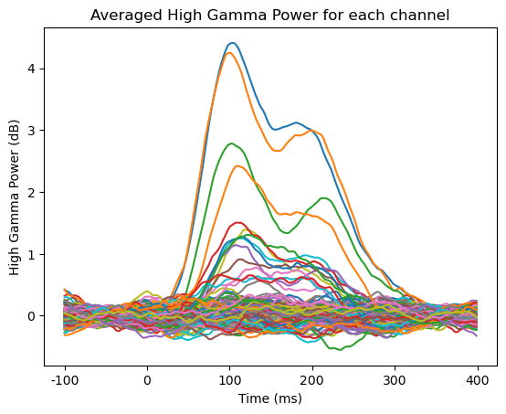

```python
hg_power = calculate_broadband_power(epoch_data,test_plot=True)
```

## Active Contact Selection

```python
def calculate_response_windows(data: np.ndarray, fs: int = 1000, onsets: int = 1000, pre_window_ms: int = 50, post_window_ms: int = 300) -> Tuple[np.ndarray, np.ndarray]:
    """
    Calculate pre- and post-stimulus response windows by averaging power across specified windows.

    Parameters:
    - data (np.ndarray): Data array of shape [n_epochs, n_channels, n_timepoints].
    - fs (int): Sampling frequency in Hz.
    - onsets (int): Index for stimulus onset.
    - pre_window_ms (int): Duration in ms before onset used for baseline response.
    - post_window_ms (int): Duration in ms after onset used for response measurement.

    Returns:
    - Tuple containing:
        - pre_responses (np.ndarray): Average power in the pre-stimulus window.
        - post_responses (np.ndarray): Average power in the post-stimulus window.
    """
    pre_samples = int(pre_window_ms * fs / 1000.0)
    post_samples = int(post_window_ms * fs / 1000.0)

    # Average across the pre-stimulus window (from onsets - pre_samples to onsets)
    pre_responses = data[:, :, onsets - pre_samples:onsets].mean(axis=2)

    # Average across the post-stimulus window (from onsets to onsets + post_samples)
    post_responses = data[:, :, onsets:onsets + post_samples].mean(axis=2)

    return pre_responses, post_responses

def perform_paired_t_test(pre_responses: np.ndarray, post_responses: np.ndarray, alpha: float = 0.001) -> pd.DataFrame:
    """
    Perform paired t-tests between pre- and post-stimulus responses for each channel.

    The function uses Bonferroni correction to adjust p-values for multiple comparisons.

    Parameters:
    - pre_responses (np.ndarray): Baseline responses.
    - post_responses (np.ndarray): Post-stimulus responses.
    - alpha (float): Significance threshold (default: 0.001).

    Returns:
    - pd.DataFrame: A DataFrame with columns ['T', 'p-val', 'p-corrected', 'significant'] for each channel.
    """
    n_channels = pre_responses.shape[1]
    results = pd.DataFrame(index=range(n_channels), columns=['T', 'p-val', 'p-corrected', 'significant'])

    for channel in range(n_channels):
        # Perform paired t-test for the current channel using pingouin
        res = pg.ttest(pre_responses[:, channel], post_responses[:, channel], paired=True)
        results.loc[channel, 'T'] = res['T'].values[0]
        results.loc[channel, 'p-val'] = res['p-val'].values[0]

    # Apply Bonferroni correction: multiply p-values by number of channels (cap at 1)
    results['p-corrected'] = results['p-val'].astype(float) * n_channels
    results['p-corrected'] = results['p-corrected'].apply(lambda x: min(x, 1))
    results['significant'] = results['p-corrected'] < alpha

    return results

def select_active_contacts(test_results: pd.DataFrame, ch_names: List[str]) -> Tuple[np.ndarray, List[str]]:
    """
    Select active contacts based on significant differences between pre- and post-stimulus responses.

    Parameters:
    - test_results (pd.DataFrame): DataFrame containing t-test results.
    - ch_names (List[str]): List of channel names.

    Returns:
    - Tuple containing:
        - active_index (np.ndarray): Array of indices for significant channels.
        - active_channel (List[str]): List of channel names corresponding to significant channels.
    """
    active_index = np.where(test_results['significant'] == True)[0]
    active_channel = [ch_names[n] for n in active_index]

    return active_index, active_channel

def plot_channel_waveforms(hg_power: np.ndarray, epoch: mne.Epochs, active_index: np.ndarray,
                           start: int = 900, end: int = 1400) -> None:
    """
    Plot the mean high gamma power waveform for each active channel.

    For each active channel, a figure with two subplots is created:
      - Left subplot: The mean waveform (averaged across all trials).
      - Right subplot: A heatmap of single-trial high gamma power (for the given time window)
        sorted by the trial’s peak latency. A dashed vertical line is added on each row
        to indicate the time of the peak latency.

    Parameters:
    - hg_power (np.ndarray): High gamma power data with shape [n_epochs, n_channels, n_timepoints].
    - epoch (mne.Epochs): MNE Epochs object (provides channel names).
    - active_index (np.ndarray): Array of channel indices for active channels.
    - start (int): Starting index for the time window to plot.
    - end (int): Ending index for the time window to plot.

    Returns:
    - None
    """
    for n in active_index:
        plt.figure(figsize=(10, 4))

        # Left subplot: Mean waveform (averaged across trials)
        plt.subplot(1, 2, 1)
        mean_waveform = hg_power.mean(axis=0)[n][start:end]
        plt.plot(mean_waveform)
        plt.title(f'{n} {epoch.ch_names[n]}')
        plt.xticks([0, 100, 200, 300, 400, 500], labels=[-100, 0, 100, 200, 300, 400])
        plt.xlabel("Time (ms)")
        plt.ylabel("High Gamma Power (dB)")
        plt.ylim(-1, 5)

        # Right subplot: Heatmap of single-trial data sorted by peak latency
        plt.subplot(1, 2, 2)
        # Extract the data for the current channel in the given window
        data = hg_power[:, n, start:end]  # shape: [n_trials, n_timepoints]

        # Determine the peak latency (index) for each trial
        peak_latencies = np.argmax(data, axis=1)

        # Sort the trials based on peak latency
        sort_order = np.argsort(peak_latencies)
        sorted_data = data[sort_order, :]
        sorted_peak_latencies = peak_latencies[sort_order]

        # Plot the heatmap using plt.imshow with origin set to "lower"
        ax = plt.gca()
        im = ax.imshow(sorted_data, aspect='auto', vmin=0, vmax=8, cmap='cividis', origin='lower')
        ax.set_xticks([0, 100, 200, 300, 400, 500])
        ax.set_xticklabels([-100, 0, 100, 200, 300, 400])
        ax.set_ylabel("Sorted Trials")
        ax.set_xlabel("Time (ms)")

        # Add dashed vertical lines indicating the peak latency for each trial
        n_trials = sorted_data.shape[0]
        for i in range(n_trials):
            peak = sorted_peak_latencies[i]
            # Draw a vertical dashed line spanning the row (from i-0.5 to i+0.5)
            ax.plot([peak, peak], [i - 0.5, i + 0.5], linestyle='--', color='white', linewidth=1)

        plt.tight_layout()
        plt.show()
```

```python
hg_pre_response, hg_post_responses = calculate_response_windows(hg_power)
test_results = perform_paired_t_test(hg_pre_response, hg_post_responses)
active_index, active_channel = select_active_contacts(test_results, epoch.ch_names)
```

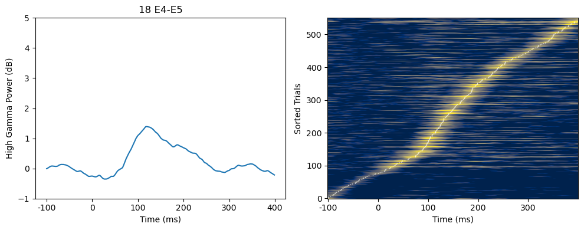

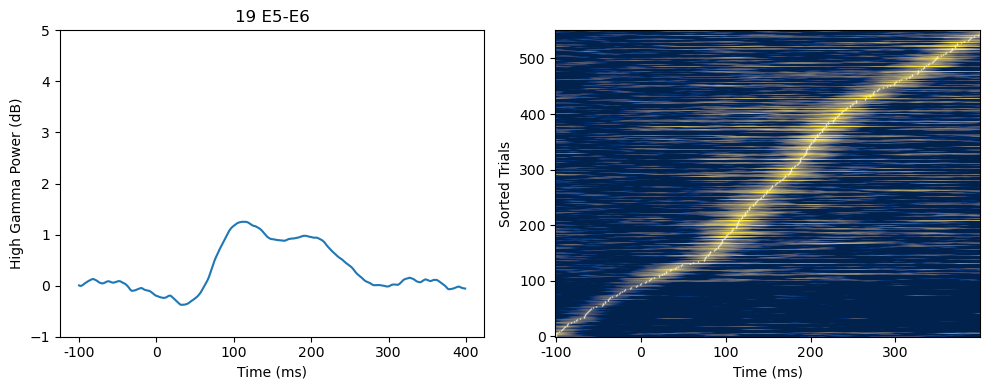

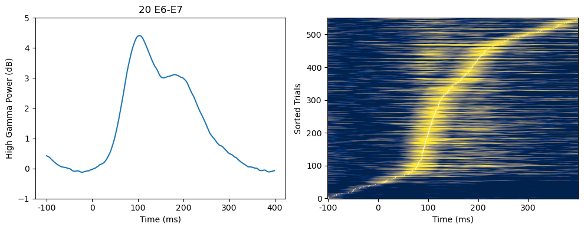

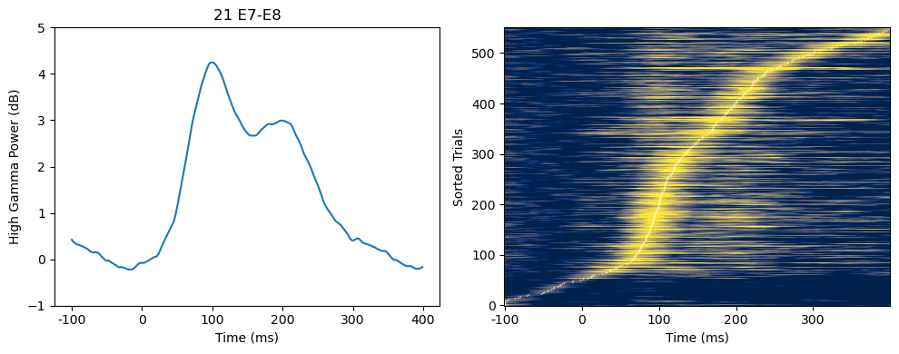

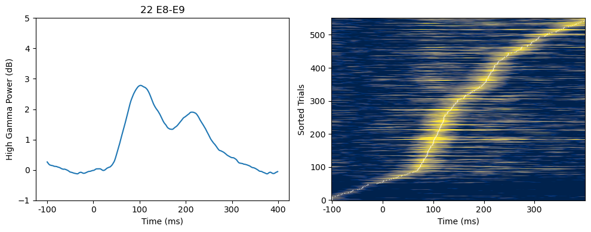

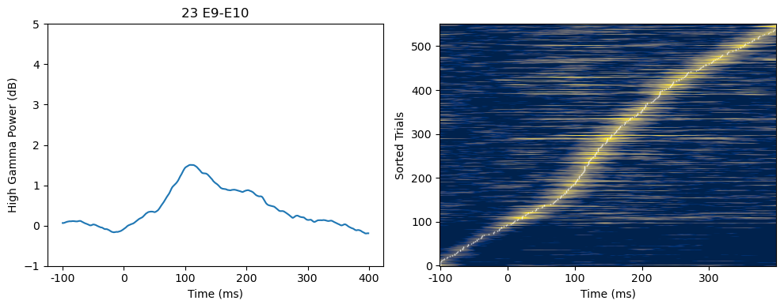

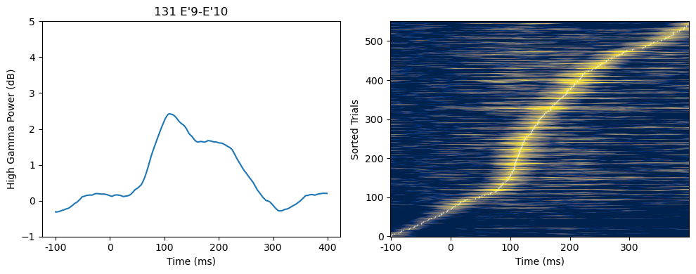

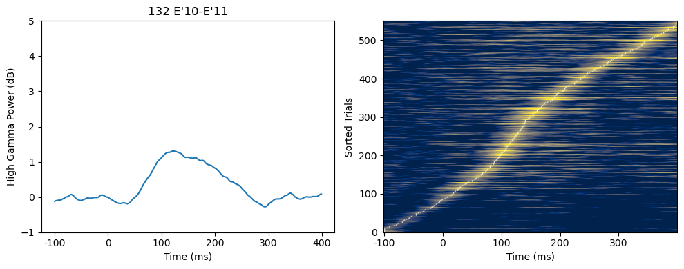

```python
plot_channel_waveforms(hg_power, epoch, active_index)
```

```python
active_index, active_channel
```

```
(array([ 18,  19,  20,  21,  22,  23, 131, 132]),
 ['E4-E5',
  'E5-E6',
  'E6-E7',
  'E7-E8',
  'E8-E9',
  'E9-E10',
  "E'9-E'10",
  "E'10-E'11"])
```

## plot active contacts

Plot active channels (mean and SEM)

```python
def plot_active_channels(data: np.ndarray, active_index: np.ndarray, epoch: mne.Epochs, start: int = 900, end: int = 1400) -> Figure:
    """
    Plot active channels in a grid layout showing mean high gamma power and standard error.

    For each active channel, the function plots the mean waveform with a shaded region representing the SEM.

    Parameters:
    - data (np.ndarray): High gamma power data of shape [n_epochs, n_channels, n_times].
    - active_index (np.ndarray): Array of indices for active channels.
    - epoch (mne.Epochs): MNE Epochs object (provides channel names).
    - start (int): Starting index for the time window to plot.
    - end (int): Ending index for the time window to plot.

    Returns:
    - Figure: Matplotlib figure object.
    """
    selected_active_contacts_index = active_index  # alias for clarity
    n_channels = len(selected_active_contacts_index)
    col = 4
    row = n_channels // col + (1 if n_channels % col else 0)
    fig, axs = plt.subplots(row, col, figsize=(col * 2.5, row * 2))
    axs = np.array(axs)

    for i in range(axs.shape[0]):
        for j in range(axs.shape[1]):
            plot_number = i * col + j
            ax = axs[i, j]
            ax.axis('off')
            if plot_number < n_channels:
                ax.axis('on')
                ax.set_xticks([])
                if j == 0:
                    ax.set_ylabel('High Gamma Power (dB)', fontsize=8)
                ax.set_xticks(np.arange(0, 501, 100))
                ax.set_xticklabels(np.arange(0, 501, 100) - 100)

                if plot_number + col >= n_channels:
                    ax.set_xlabel('Time (ms)')
                else:
                    ax.set_xlabel('')

                # Extract channel data and compute mean and SEM
                channel_index = active_index[plot_number]
                channel_data = data[:, channel_index, start:end]
                channel_mean = channel_data.mean(axis=0)
                channel_sem = stats.mstats.sem(channel_data, axis=0)
                channel_x = np.arange(0, end - start)

                ax.plot(channel_x, channel_mean, color='k', alpha=0.8)
                ax.fill_between(channel_x, channel_mean + channel_sem, channel_mean - channel_sem,
                                color='k', alpha=0.2)
                y_max = 6
                ax.set_yticks([0, y_max//2, y_max])
                ax.plot([100, 100], [-1, y_max], color='red', alpha=0.5, linestyle='--', linewidth=1)
                ax.set_ylim(-1, y_max)
                ax.set_title(f"{epoch.ch_names[channel_index]}")
                for spine in ax.spines.values():
                    spine.set_edgecolor('grey')
                    spine.set_linewidth(0.5)

    plt.suptitle('Significant Channels, high gamma power', fontsize=15)
    plt.tight_layout()
    plt.show()
    return fig
```

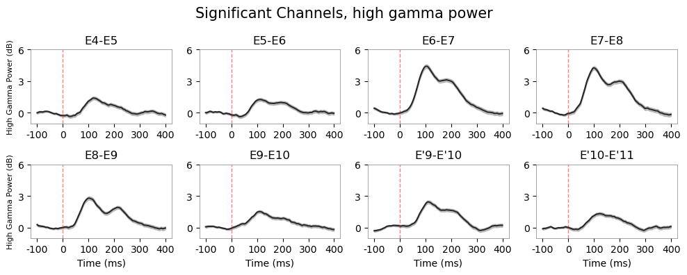

```python
active_contact_figure = plot_active_channels(hg_power, active_index, epoch)
active_contact_figure.savefig(f"{img_path}HGP_active_channel.png", dpi=300)
```

# ERP

This section demonstrates the processing of ERP data by:

1. Loading and resampling ERP epoch data.
2. Plotting ERP waveforms for active channels.

Modules:

## Data Loader

```python
def load_and_resample_epoch(epoch_file: str, resample_rate: int = 1000) -> Tuple[mne.Epochs, np.ndarray]:
    """
    Load epoch data from a file and resample it.

    Parameters:
    - epoch_file: string, file path to the MNE epoch file.
    - resample_rate: int, new sampling rate (default is 1000 Hz).

    Returns:
    - epoch: MNE Epochs object after resampling.
    - epoch_data: numpy array of shape [n_epochs, n_channels, n_timepoints].
    """
    # Load the epochs from file
    epoch = mne.read_epochs(epoch_file)

    # Resample the data to the desired sampling rate
    epoch.resample(resample_rate)

    # Get the data as a numpy array
    epoch_data = epoch.copy().get_data()

    return epoch, epoch_data
```

```python
epoch, epoch_data = load_and_resample_epoch(epochERPFile_name)
```

```
Reading /home/haozhu/Personal/demo_bipolar/QUJ3YH24KM_epoch_erp-epo.fif ...
Isotrak not found
    Found the data of interest:
        t =    -100.10 ...     399.90 ms
        0 CTF compensation matrices available
Not setting metadata
551 matching events found
No baseline correction applied
0 projection items activated
```

## plot active contacts erp

```python
def plot_active_channel_erp(data: np.ndarray,
                            selected_active_channel_names: list[str],
                            epoch: mne.Epochs,
                            plot_start: int = 0,
                            plot_end: int = 500) -> Figure:
    """
    Plot the ERP (voltage over time) for active channels.

    This function creates a grid of subplots where each subplot shows the mean ERP waveform
    (with standard error shading) for an active channel. Instead of using channel indices,
    it accepts a list of active channel names. For each channel, the function determines its
    index in the epoch and then extracts the ERP data for plotting.

    Parameters:
      - data (np.ndarray): ERP epoch data with shape [n_epochs, n_channels, n_timepoints].
      - selected_active_channel_names (List[str]): List of active channel names.
      - epoch (mne.Epochs): MNE Epochs object (provides channel names).
      - plot_start (int): Starting index for the time window to plot (default is 0).
      - plot_end (int): Ending index for the time window to plot (default is 500).

    Returns:
      - Figure: Matplotlib figure object containing the ERP plots.
    """
    # Determine the number of active channels based on the provided list
    n_channels = len(selected_active_channel_names)

    # Define grid dimensions: 4 columns; number of rows is computed based on number of active channels.
    col = 4
    row = n_channels // col + (1 if n_channels % col != 0 else 0)

    # Create the figure and axes for subplots
    fig, axs = plt.subplots(row, col, figsize=(col * 2.5, row * 2))
    print("Axes shape:", np.shape(axs))

    # Define the x-axis for the plot: samples within the specified time window
    channel_x = np.arange(plot_end - plot_start)
    # Set x-tick positions and labels (assuming index 0 corresponds to -100 ms and index 100 to 0 ms)
    xtick_positions = np.arange(0, (plot_end - plot_start)+1, 100)
    xtick_labels = (xtick_positions - 100).tolist()

    ymax = 6  # Maximum voltage value for plotting (in arbitrary units)

    # Loop over the subplot grid and plot ERP for each active channel
    for i in range(row):
        for j in range(col):
            plot_number = i * col + j
            # Handle cases when axs is 1D or 2D depending on number of rows/columns
            ax = axs[i, j] if row > 1 else axs[j]
            ax.axis('off')
            if plot_number < n_channels:
                ax.axis('on')
                if j == 0:
                    ax.set_ylabel('Voltage (10µV)')
                ax.set_xticks(xtick_positions)
                ax.set_xticklabels(xtick_labels)
                if i == row - 1:
                    ax.set_xlabel('Time (ms)')

                # Get the channel name from the provided active channel list
                channel_name = selected_active_channel_names[plot_number]
                # Find the corresponding index in epoch.ch_names
                try:
                    channel_index = epoch.ch_names.index(channel_name)
                except ValueError:
                    raise ValueError(f"Channel name {channel_name} not found in epoch.ch_names.")

                # Extract ERP data for the current channel across all trials in the defined window
                channel_data = data[:, channel_index, plot_start:plot_end]
                # Compute the mean ERP waveform and standard error across trials
                channel_mean = channel_data.mean(axis=0) * 1e5
                channel_sem = stats.mstats.sem(channel_data, axis=0) * 1e5

                # Plot the mean ERP waveform
                ax.plot(channel_x, channel_mean, color='k', alpha=0.8)
                # Plot the shaded standard error region
                ax.fill_between(channel_x, channel_mean + channel_sem, channel_mean - channel_sem,
                                color='k', alpha=0.2)

                # Define x-axis limits (in samples)
                xlims = [-20, 525]
                # Define y-ticks for voltage display (for example, from -ymax to ymax in steps of 4)
                channel_y = np.arange(-ymax, ymax + 0.01, 4).astype(int)
                ax.set_yticks(channel_y)
                ax.set_yticklabels(channel_y, fontsize=8)

                # Draw a vertical dashed line at time 0 (which corresponds to index 100)
                ax.plot([100, 100], [-ymax, ymax], color='k', linewidth=1, linestyle=(0, [1, 1]))
                # ax.set_ylim(-ymax, ymax)
                ax.set_xlim(xlims)
                # Set the subplot title to the active channel name
                ax.set_title(f"{channel_name}")
                # Draw a horizontal dashed line at 0 voltage
                ax.plot(xlims, [0, 0], 'k', linewidth=1, linestyle=(0, [1, 1]))
                # Hide the top and right spines for a cleaner appearance
                ax.spines['top'].set_visible(False)
                ax.spines['right'].set_visible(False)

    plt.suptitle('Significant Channels, ERP', fontsize=15)
    plt.tight_layout()
    plt.show()

    return fig
```

```python
active_channel = ['E4-E5',
  'E5-E6',
  'E6-E7',
  'E7-E8',
  'E8-E9',
  'E9-E10',
  "E'9-E'10",
  "E'10-E'11"]
```

```
Axes shape: (2, 4)
```

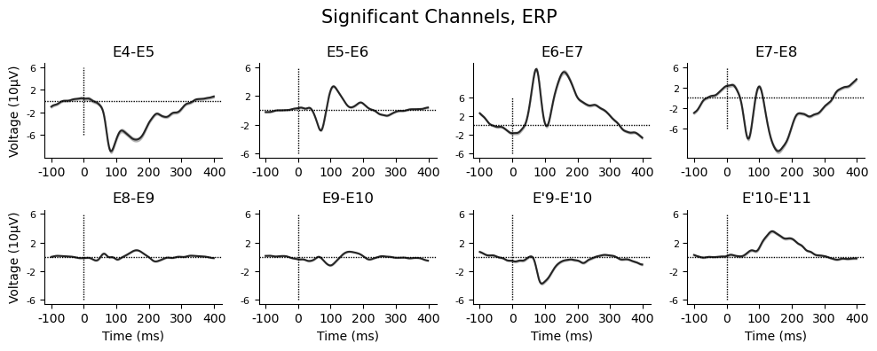

```python
# Plot ERP for the active channels using the ERP epoch data
active_erp_fig = plot_active_channel_erp(epoch_data, active_channel, epoch, plot_start=0, plot_end=500)

# Save the ERP figure
active_erp_fig.savefig(f"{img_path}ERP_active_channel.png", dpi=300)
```

# BBP

This section demonstrates the processing of BBP data by:

1. Loading and resampling BBP epoch data.
2. Computing normalized spectrograms
3. Plotting spectrograms for active channels.

## Data Loader

```python
def load_and_resample_epoch(epoch_file: str, resample_rate: int = 1000) -> mne.Epochs:
    """
    Load epoch data from a file and resample it.

    Parameters:
    - epoch_file: string, file path to the MNE epoch file.
    - resample_rate: int, new sampling rate (default is 1000 Hz).

    Returns:
    - epoch: MNE Epochs object after resampling.
    - epoch_data: numpy array of shape [n_epochs, n_channels, n_timepoints].
    """
    # Load the epochs from file
    epoch = mne.read_epochs(epoch_file)

    # Resample the data to the desired sampling rate
    epoch.resample(resample_rate)

    return epoch

def extract_active_channels(epoch: mne.Epochs, active_channels: List[str]) -> np.ndarray:
    """
    Extract data corresponding to active channels from the epoch object.

    Parameters
    ----------
    epoch : mne.Epochs
        The MNE epochs object containing the sEEG data.
    active_channels : List[str]
        List of channel names to extract.

    Returns
    -------
    data : np.ndarray
        NumPy array of shape (n_trials, n_active_channels, n_samples) with the extracted data.
    """
    data = epoch.copy().pick(active_channels).get_data()

    return data
```

```python
active_channel = ['E4-E5',
  'E5-E6',
  'E6-E7',
  'E7-E8',
  'E8-E9',
  'E9-E10',
  "E'9-E'10",
  "E'10-E'11"]
epoch = load_and_resample_epoch(epochBBPFile_name)
epoch_data = extract_active_channels(epoch, active_channel)
```

```
Reading /home/haozhu/Personal/demo_bipolar/QUJ3YH24KM_epoch_bbp-epo.fif ...
Isotrak not found
    Found the data of interest:
        t =    -100.10 ...     399.90 ms
        0 CTF compensation matrices available
Not setting metadata
551 matching events found
No baseline correction applied
0 projection items activated
```

## Spectrogram

Module for computing spectrograms from sEEG trial data using a sliding window DFT.

### computing spectrograms

```python
def compute_spectrogram(trial_data: np.ndarray, window: int, overlap: int, nfft: np.ndarray, sample_rate: float
                       ) -> Tuple[np.ndarray, np.ndarray, np.ndarray, np.ndarray]:
    """
    Compute a spectrogram for a single trial's data using a sliding window Discrete Fourier Transform (DFT).

    This function mimics MATLAB's spectrogram(small_segment, window, overlap, nfft, sample_rate, 'yaxis')
    by applying a Hamming window to each segment, computing the DFT at specified frequency points,
    and then calculating the power spectrum.

    Parameters
    ----------
    trial_data : np.ndarray
        1D array containing the signal from one trial (a single channel).
    window : int
        Length of the window (in samples) for the sliding DFT.
    overlap : int
        Number of samples overlapping between adjacent windows.
    nfft : np.ndarray
        1D array of frequency points (in Hz) at which to compute the DFT.
    sample_rate : float
        Sampling rate in Hz.

    Returns
    -------
    S : np.ndarray
        Complex spectrogram matrix of shape (len(nfft), n_windows) with DFT values.
    F : np.ndarray
        Frequency vector (in Hz) corresponding to the rows of S (same as input nfft).
    T : np.ndarray
        Time vector (in seconds) corresponding to the center of each window.
    P : np.ndarray
        Power spectrogram computed as the magnitude squared of S.
    """
    # Compute the step size (non-overlapping samples)
    step = window - overlap
    if step < 1:
        step = 1  # Ensure at least one sample step

    # Determine the number of segments (windows) that fit into the trial data.
    n_segments = (len(trial_data) - window) // step + 1

    # Precompute the DFT exponent matrix.
    n = np.arange(window)  # Sample indices for one window
    E = np.exp(-1j * 2 * np.pi * np.outer(nfft, n) / sample_rate)  # Shape: (len(nfft), window)

    # Create a Hamming window of the specified length.
    w = np.hamming(window)

    # Preallocate arrays for the spectrogram and time vector.
    S = np.empty((len(nfft), n_segments), dtype=complex)
    T = np.empty(n_segments)

    # Process each segment.
    for i in range(n_segments):
        start = i * step
        segment = trial_data[start: start + window]
        segment = segment * w  # Apply the Hamming window.
        S[:, i] = E @ segment  # Compute the DFT.
        T[i] = (start + window / 2) / sample_rate  # Center time of the window.

    P = np.abs(S) ** 2  # Power spectrogram.
    F = nfft  # Frequency vector.

    return S, F, T, P
```

```python
"""
Module for processing sEEG data per channel and per trial in parallel.
This module leverages the compute_spectrogram() function.
"""
def process_channel_wrapper(args: Tuple) -> Tuple[int, np.ndarray, np.ndarray, np.ndarray]:
    """
    Helper function to process a single channel across multiple trials.

    For each trial, a segment of data is extracted, the spectrogram is computed,
    and the power is normalized by converting to dB and subtracting a baseline.

    Parameters
    ----------
    args : Tuple
        A tuple containing:
            - j (int): Channel index.
            - data (np.ndarray): 3D array with shape (n_trials, n_channels, n_samples).
            - task_trials (int): Number of trials to process.
            - time_start (int): Starting sample offset for segment extraction.
            - window (int): Window length in samples for the spectrogram.
            - overlap (int): Number of overlapping samples between windows.
            - nfft (np.ndarray): Frequency points for the DFT.
            - sample_rate (float): Sampling rate in Hz.

    Returns
    -------
    j : int
        Channel index.
    local_spectro : np.ndarray
        3D array of normalized power spectrograms for the channel with shape
        (n_frequencies, n_time_bins, task_trials).
    local_T : np.ndarray
        Time vector (in seconds) computed for the channel.
    local_F : np.ndarray
        Frequency vector (in Hz) computed for the channel.
    """
    j, data, task_trials, time_start, window, overlap, nfft, sample_rate = args
    local_spectro_list = []
    local_T = None
    local_F = None

    for i in range(task_trials):
        # Extract a segment from the trial (samples 0 to time_start+399).
        small_segment = data[i, j, :time_start+399].flatten()
        S, F, T, P = compute_spectrogram(small_segment, window, overlap, nfft, sample_rate)

        # Convert power to dB and perform baseline normalization.
        logged_P = 10 * np.log10(P + np.finfo(float).eps)
        base_db = np.mean(logged_P[:, 50:100], axis=1, keepdims=True)
        norm_P = logged_P - base_db

        local_spectro_list.append(norm_P)
        if i == 0:
            local_T = T
            local_F = F

    local_spectro = np.stack(local_spectro_list, axis=-1)
    return j, local_spectro, local_T, local_F

def process_data(data: np.ndarray, good_channels: int, task_trials: int, time_start: int,
                 window: int, overlap: int, nfft: np.ndarray, sample_rate: float
                ) -> Tuple[np.ndarray, np.ndarray, np.ndarray]:
    """
    Process the data for each channel and trial in parallel by computing normalized spectrograms.

    Parameters
    ----------
    data : np.ndarray
        3D array of shape (n_trials, n_channels, n_samples).
    good_channels : int
        Number of channels to process.
    task_trials : int
        Number of trials to process.
    time_start : int
        Starting sample offset (e.g., 100). The segment is extracted from 0 to time_start+399.
    window : int
        Window length (in samples) for spectrogram computation.
    overlap : int
        Number of overlapping samples between consecutive windows.
    nfft : np.ndarray
        Frequency points (in Hz) at which the DFT is computed.
    sample_rate : float
        Sampling rate in Hz.

    Returns
    -------
    spectro : np.ndarray
        4D array of normalized power spectrograms with shape
        (n_frequencies, n_time_bins, task_trials, good_channels).
    T_values : np.ndarray
        2D array where each column is the time vector for a channel.
    F_values : np.ndarray
        2D array where each column is the frequency vector for a channel.
    """
    start_time = time.time()

    # Determine output dimensions using the first trial and first channel.
    sample_segment = data[0, 0, :time_start+399].flatten()
    _, F_sample, T_sample, P_sample = compute_spectrogram(sample_segment, window, overlap, nfft, sample_rate)
    n_frequencies, n_time_bins = P_sample.shape
    n_T = len(T_sample)
    n_F = len(F_sample)

    # Preallocate output arrays.
    spectro = np.full((n_frequencies, n_time_bins, task_trials, good_channels), np.nan)
    T_values = np.full((n_T, good_channels), np.nan)
    F_values = np.full((n_F, good_channels), np.nan)

    # Prepare arguments for parallel processing.
    args_list = [
        (j, data, task_trials, time_start, window, overlap, nfft, sample_rate)
        for j in range(good_channels)
    ]

    # Process channels in parallel.
    with ProcessPoolExecutor(max_workers=1) as executor:
        futures = [executor.submit(process_channel_wrapper, args) for args in args_list]
        for future in as_completed(futures):
            j, local_spectro, local_T, local_F = future.result()
            spectro[:, :, :, j] = local_spectro
            T_values[:, j] = local_T
            F_values[:, j] = local_F
            print(f"Processed channel {j+1} of {good_channels}")

    end_time = time.time()
    print(f"Total processing time: {end_time - start_time:.2f} seconds")

    return spectro, T_values, F_values
```

```python
# Define spectrogram and processing parameters.
good_channels: int = epoch_data.shape[1]       # Number of channels to process.
task_trials: int = epoch_data.shape[0]           # Number of trials.
time_start: int = 100                            # Starting sample offset.
window: int = 40                                 # Window length in samples.
overlap: int = 38                                # Number of overlapping samples.
nfft: np.ndarray = np.arange(1, 204, 5)           # Frequency vector (1 Hz to ~200 Hz).
sample_rate: int = 1000                          # Sampling rate in Hz.
if __name__ == "__main__":
    # For example, data = np.random.randn(task_trials, total_channels, n_samples)
    spectro, T_values, F_values = process_data(epoch_data, good_channels, task_trials, time_start, window, overlap, nfft, sample_rate)
```

```
Processed channel 1 of 8
Processed channel 2 of 8
Processed channel 3 of 8
Processed channel 4 of 8
Processed channel 5 of 8
Processed channel 6 of 8
Processed channel 7 of 8
Processed channel 8 of 8
Total processing time: 3.04 seconds
```

### plot spectrograms

```python
def plot_spectrogram(spectro: np.ndarray, T_values: np.ndarray, F_values: np.ndarray,
                     channel_titles: List[str] = None, save: bool = False,
                     top_color: float = 2, bottom_color: float = 0, n_cols: int = 4) -> None:
    """
    Plot the spectrogram for multiple channels by averaging over trials.

    Parameters
    ----------
    spectro : np.ndarray
        4D array of normalized power spectrograms with shape
        (n_frequencies, n_time_bins, task_trials, n_channels).
    T_values : np.ndarray
        2D array where each column is the time vector (in seconds) for a channel.
    F_values : np.ndarray
        2D array where each column is the frequency vector (in Hz) for a channel.
    channel_titles : List[str], optional
        List of channel titles. Defaults to "Channel 1", "Channel 2", etc. if not provided.
    save : bool, optional
        If True, the figure is saved to the path specified by img_path (default is False).
    top_color : float, optional
        Upper limit for color scaling (default is 2).
    bottom_color : float, optional
        Lower limit for color scaling (default is 0).
    n_cols : int, optional
        Number of subplot columns (default is 4).

    Returns
    -------
    None
        The function plots the spectrogram and optionally saves the figure.
    """
    # Adjust time axis: shift by -100ms and convert seconds to milliseconds.
    T_correct = (T_values - 0.1) * 1000  # in ms

    n_channels = spectro.shape[-1]
    n_rows = -(-n_channels // n_cols)  # Ceiling division

    fig, axs = plt.subplots(n_rows, n_cols, figsize=(n_cols * 2.5, n_rows * 2))
    axs = axs.flatten()

    for i in range(n_channels):
        select_P = spectro[:, :, :, i]
        averaged_P = np.nanmean(select_P, axis=2)
        ax = axs[i]
        im = ax.imshow(averaged_P, aspect='auto',
                       extent=[T_correct.min(), T_correct.max(), F_values.min(), F_values.max()],
                       cmap='cividis', vmin=bottom_color, vmax=top_color, origin='lower')

        if channel_titles is not None and i < len(channel_titles):
            ax.set_title(channel_titles[i], fontsize=12)
        else:
            ax.set_title(f"Channel {i+1}", fontsize=12)

        ax.set_ylim([50, 200])
        ax.set_yticks([50, 100, 150, 200])
        if i % n_cols == 0:
            ax.set_ylabel('Frequency (Hz)')
        else:
            ax.set_ylabel('')

        ax.set_xticks([0, 100, 200, 300])
        if i + n_cols >= n_channels:
            ax.set_xlabel('Time (ms)')
        else:
            ax.set_xlabel('')

    for j in range(n_channels, len(axs)):
        axs[j].axis('off')

    plt.suptitle('Significant Channels, Spectrogram', fontsize=15)
    fig.tight_layout(rect=[0, 0, 0.9, 1])

    cbar_ax = fig.add_axes([0.92, 0.15, 0.02, 0.7])
    cbar = fig.colorbar(im, cax=cbar_ax, ticks=[0, 1, 2, 3, 4])
    cbar.set_label('Normalized Power (dB)', fontsize=10)

    if save:
        save_filename = f"{img_path}Spectro_active_channel.png"
        plt.savefig(save_filename, dpi=300, bbox_inches='tight')
        print(f"Figure saved to {save_filename}")

    plt.show()
```

```
Figure saved to figures/Spectro_active_channel.png
```

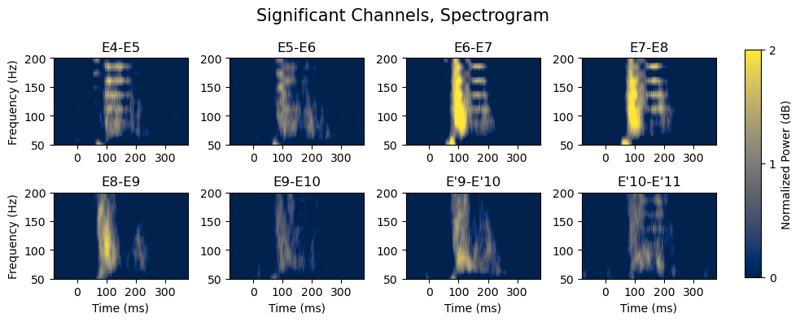

```python
plot_spectrogram(spectro, T_values, F_values, channel_titles=active_channel, save=True)
```